# HW 7

Jan Netík

### 1.1.1

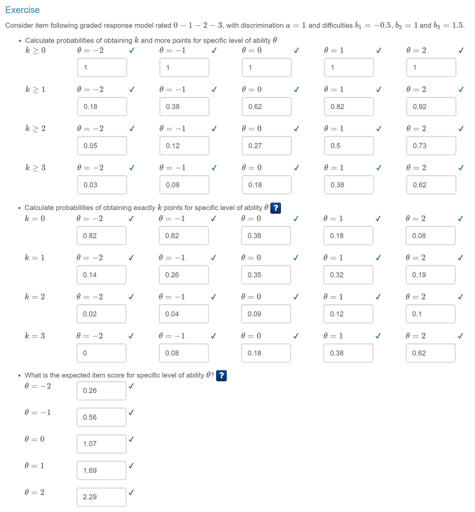

### 1.1.2

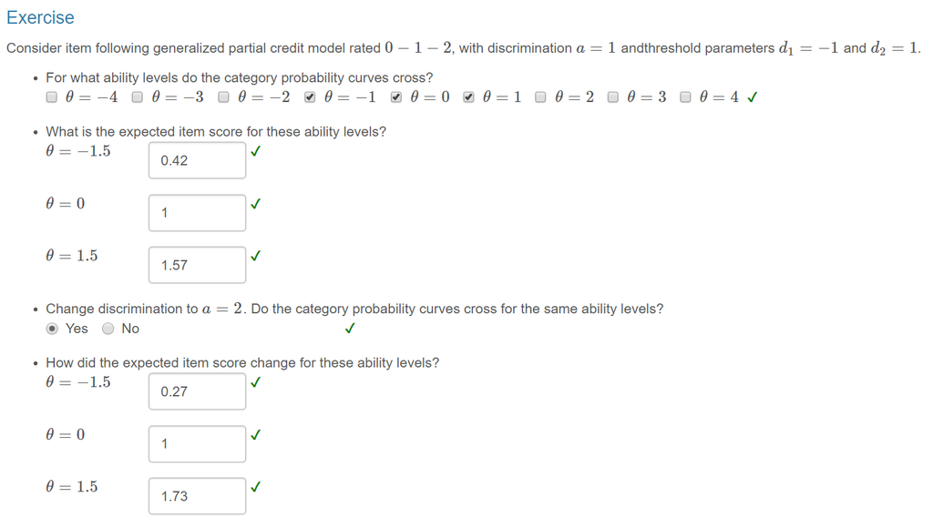

### 2.1.1

```r
data <- read.csv("neuroticism500.csv", header = T, row.names = 1)

ncol(data)
```

```
## [1] 5
```

```r
nrow(data)
```

```
## [1] 500
```

$N_{items} = 5$  
$N_{observations}=500$

### 2.1.2

```r
sort(unique(data$V1))
```

```
## [1] 1 2 3 4 5 6
```

Items are rated using Likert-type scale *1–2–3–4–5–6*.

### 2.2.1

```r
s <- 'F = 1-5
CONSTRAIN = (1-5, a1)'

fitGRM1 <- mirt(data = data, model = s, itemtype = "graded")
```

*Output suppressed.*

```r
constr <- coef(fitGRM1, simplify = T)
constr$items %>% pander(digits = 2)
```

|  | a1 | d1 | d2 | d3 | d4 | d5 |
| --- | --- | --- | --- | --- | --- | --- |
| **V1** | 1.8 | 2.1 | 0.31 | -0.7 | -2.2 | -3.9 |
| **V2** | 1.8 | 3.2 | 1.3 | 0.42 | -1.5 | -3.2 |
| **V3** | 1.8 | 2.5 | 0.7 | -0.24 | -1.7 | -3.3 |
| **V4** | 1.8 | 2.7 | 0.73 | -0.23 | -1.9 | -3.5 |
| **V5** | 1.8 | 1.6 | -0.11 | -0.97 | -2.1 | -3.5 |

### 2.2.2

```r
fitGRM2 <- mirt(data = data, model = 1, itemtype = "graded")
```

*Output suppressed.*

```r
no_constr <- coef(fitGRM2, simplify = T)
no_constr$items %>% pander(digits = 2)
```

|  | a1 | d1 | d2 | d3 | d4 | d5 |
| --- | --- | --- | --- | --- | --- | --- |
| **V1** | 3.3 | 3.1 | 0.48 | -1 | -3.2 | -5.8 |
| **V2** | 3 | 4.5 | 1.8 | 0.58 | -2.1 | -4.3 |
| **V3** | 1.9 | 2.5 | 0.74 | -0.2 | -1.7 | -3.3 |
| **V4** | 1.1 | 2.3 | 0.62 | -0.17 | -1.6 | -3 |
| **V5** | 0.99 | 1.3 | -0.089 | -0.78 | -1.7 | -2.8 |

### 2.2.3

```r
anova(fitGRM1, fitGRM2) %>% pander(digits = 2)
```

```
##
## Model 1: mirt(data = data, model = s, itemtype = "graded")
## Model 2: mirt(data = data, model = 1, itemtype = "graded")
```

| AIC | AICc | SABIC | HQ | BIC | logLik | X2 | df | p |
| --- | --- | --- | --- | --- | --- | --- | --- | --- |
| 7864 | 7867 | 7891 | 7907 | 7973 | -3906 | NA | NA | NA |
| 7777 | 7781 | 7808 | 7826 | 7903 | -3858 | 95 | 4 | 0 |

According to the likelihood ratio test (*p* < .001) and several criteria shown above, unconstrained model (*GRM2*) fits better that constrained.

### 2.2.4

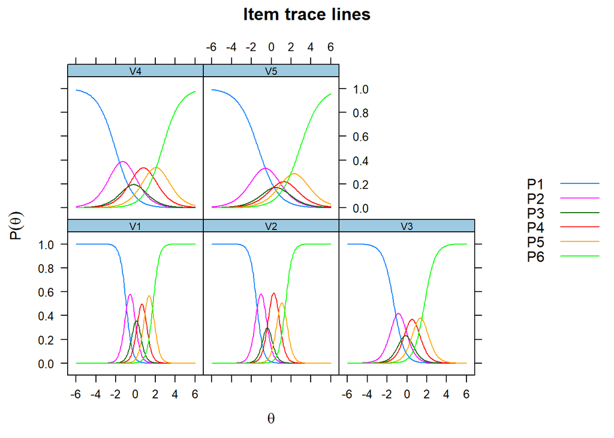

```r
plot(fitGRM2, type = "trace")
```

### 2.2.5

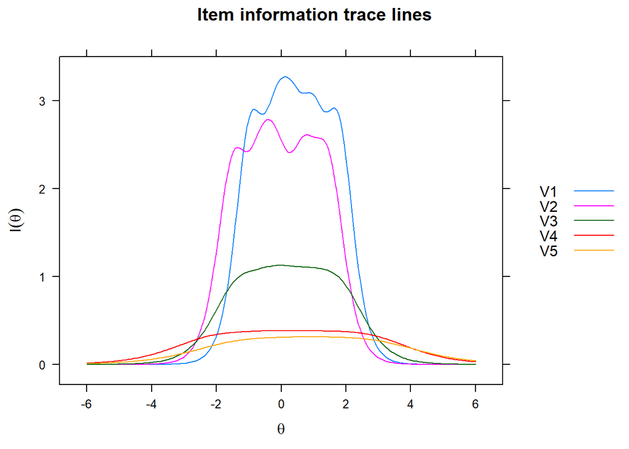

```r
plot(fitGRM2, type = "infotrace", facet_items = F)
```

### 2.2.6

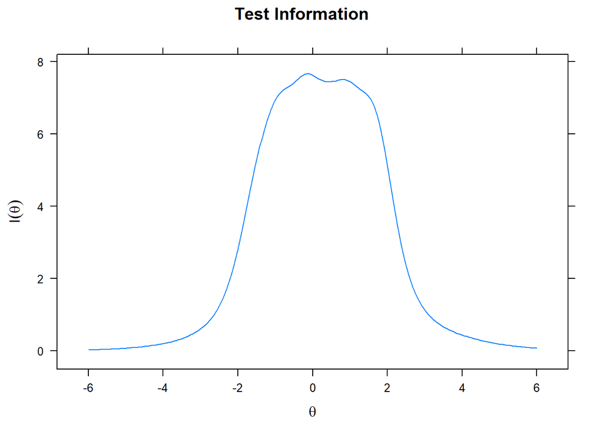

```r
plot(fitGRM2, type = "info")
```

Maximum information is provided around $\theta = 0$.

### 3.1.1

70

### 3.1.2

a five-point grade scale

### 3.1.3

the same 90 essays

### 3.2.1

by fitting PCM model, treating the markers as “items” and essays as “cases”

### 3.2.2

essay number 61

### 3.2.3

essay number 53

### 3.2.4

grades which the essay number 22 received the most are “C” and “B”

### 3.3.1

> For each marker, the partial credit analysis had provided a set of threshold estimates, which had been used to mark out regions (shaded) reflecting that marker’s use of the five-point grade scale.

### 3.3.2

The typical marker has thresholds location “of”between" lenient and harsh marker, whereas the “noncommittal” presents with “diffused” thresholds (information function has relatively high SD).

### 3.3.3

> Each of these four markers displayed good fit to the PCM. Their ratings were in good agreement with the general ordering of these essays on the variable.

### 3.3.4

> Partial credit analysis can be used in this way to identify differences among markers in their use of the provided grade points. Once markers are calibrated, differences in marker behavior could be taken into account automatically in future marking exercises.